# Ecommerce Funnel & Attribution Analysis

IBM 6530 · Deliverable 2 — Final Quarto Report

Author

Bansi Khachar, Matthew Prado, Lucynda Young, Saurabh Parate

Published

May 6, 2026

## Narrative Summary of the Business Problem

The data reveals that users are actively engaging with the platform but are abandoning the funnel at multiple stages before reaching purchase. The core business problem is not a lack of traffic; it is a broken conversion architecture that is leaking potential revenue at every stage of the funnel, with the most severe losses occurring at the product discovery stage.

**Why it matters:**

- High traffic with low conversion signals a disconnect between user intent and purchase completion
- Unidentified drop-off points make it impossible to allocate marketing spend efficiently
- Without attribution data, the business cannot determine which funnel stages drive the most conversions

## Setup & Data Connection

```r
library(DBI)
library(bigrquery)
library(dplyr)
library(dbplyr)
library(ggplot2)
library(scales)
library(knitr)
library(kableExtra)
library(ChannelAttribution)
library(tidyr)
library(htmltools)

bigrquery::bq_auth(
  scopes = "https://www.googleapis.com/auth/bigquery"
)

project_id <- "ga4-analysis-491223"

mart_project <- "bigquery-public-data"
mart_dataset <- "ga4_obfuscated_sample_ecommerce"
mart_view <- "events_20210131"

con <- DBI::dbConnect(
  bigrquery::bigquery(),
  project = mart_project,
  dataset = mart_dataset,
  billing = project_id
)

mart_tbl <- dplyr::tbl(con, mart_view)
```

## Descriptive Insights

### Core KPIs

```r
kpis <- mart_tbl |>
  summarise(
    total_events   = n(),
    distinct_users = n_distinct(user_pseudo_id),
    purchases      = sum(as.integer(event_name == "purchase"), na.rm = TRUE)
  ) |>
  collect() |>
  mutate(cvr = paste0(round(purchases / distinct_users * 100, 1), "%"))

kpis |>
  kable(
    col.names = c("Total Events", "Distinct Users", "Purchases", "CVR"),
    align     = "c",
    caption   = "Core KPIs — GA4 Obfuscated Sample, Jan 31 2021"
  ) |>
  kable_styling(full_width = FALSE, bootstrap_options = c("striped", "hover"))
```

Core KPIs — GA4 Obfuscated Sample, Jan 31 2021

| Total Events | Distinct Users | Purchases | CVR |
| --- | --- | --- | --- |
| 26489 | 2546 | 19 | 0.7% |

### Funnel Performance

```r
funnel_order <- c("page_view", "view_item", "add_to_cart",
                  "begin_checkout", "purchase")

funnel <- mart_tbl |>
  filter(event_name %in% funnel_order) |>
  group_by(event_name) |>
  summarise(users = n_distinct(user_pseudo_id)) |>
  collect() |>
  mutate(event_name = factor(event_name, levels = funnel_order)) |>
  arrange(event_name) |>
  mutate(
    cvr     = paste0(round(users / first(users) * 100, 1), "%"),
    dropoff = paste0(round(
      (1 - users / lag(users, default = first(users))) * 100, 1
    ), "%")
  )

funnel |>
  kable(
    col.names = c("Event", "Users", "CVR", "Drop-off"),
    align     = "c",
    caption   = "Funnel Performance — Distinct Users by Stage"
  ) |>
  kable_styling(full_width = FALSE, bootstrap_options = c("striped", "hover")) |>
  row_spec(2, color = "#a32d2d") |>
  row_spec(3, color = "#a32d2d") |>
  row_spec(5, color = "#a32d2d")
```

Funnel Performance — Distinct Users by Stage

| Event | Users | CVR | Drop-off |
| --- | --- | --- | --- |
| page_view | 2499 | 100% | 0% |
| view_item | 539 | 21.6% | 78.4% |
| add_to_cart | 98 | 3.9% | 81.8% |
| begin_checkout | 54 | 2.2% | 44.9% |
| purchase | 17 | 0.7% | 68.5% |

### Funnel Bar Chart

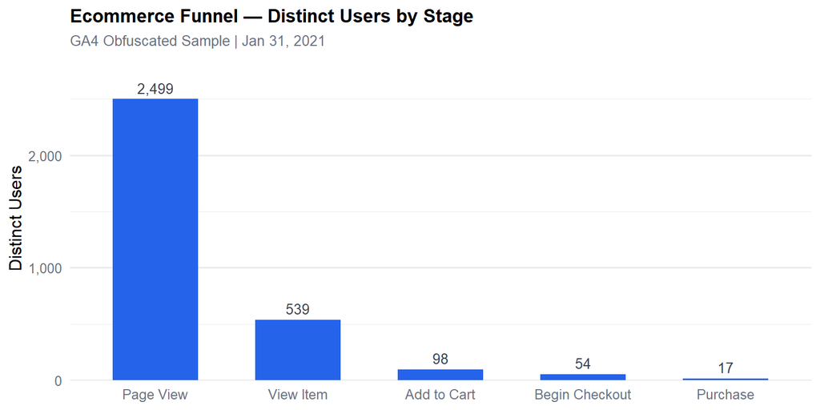

```r
ggplot(funnel, aes(x = event_name, y = users)) +
  geom_col(fill = "#2563EB", width = 0.6) +
  geom_text(
    aes(label = scales::comma(users)),
    vjust = -0.5, size = 3.5, color = "#374151"
  ) +
  scale_x_discrete(
    labels = c("Page View", "View Item", "Add to Cart",
               "Begin Checkout", "Purchase")
  ) +
  scale_y_continuous(
    labels = scales::comma,
    expand = expansion(mult = c(0, 0.15))
  ) +
  labs(
    title    = "Ecommerce Funnel — Distinct Users by Stage",
    subtitle = "GA4 Obfuscated Sample | Jan 31, 2021",
    x        = NULL,
    y        = "Distinct Users"
  ) +
  theme_minimal(base_size = 12) +
  theme(
    plot.title    = element_text(face = "bold", size = 13),
    plot.subtitle = element_text(color = "#6B7280", size = 10),
    axis.text     = element_text(color = "#6B7280"),
    panel.grid.major.x = element_blank()
  )
```

**Interpretation:** The bar chart makes the funnel collapse immediately visible. The dramatic drop from 2,499 page views to 539 product views is the single biggest opportunity — most users are bouncing before they ever see a product.

## Advanced Analysis — Attribution

### Methodology

```r
# Step 1 — pull purchaser IDs into local memory
purchaser_ids <- mart_tbl |>
  filter(event_name == "purchase") |>
  select(user_pseudo_id) |>
  distinct() |>
  collect() |>
  pull(user_pseudo_id)

# Step 2 — pull all funnel events for converting users
purchasers <- mart_tbl |>
  filter(
    user_pseudo_id %in% purchaser_ids,
    event_name     %in% funnel_order
  ) |>
  select(user_pseudo_id, event_name) |>
  collect()

# Step 3 — build channel_stack for ChannelAttribution
channel_stack <- purchasers |>
  group_by(user_pseudo_id) |>
  summarise(
    cleaned_path = paste(event_name, collapse = ">"),
    .groups      = "drop"
  ) |>
  mutate(
    conversion     = 1,
    non_conversion = 0
  ) |>
  group_by(cleaned_path) |>
  summarise(
    conversion     = sum(conversion),
    non_conversion = sum(non_conversion),
    .groups        = "drop"
  )
```

**Unit of analysis:** Individual user session tracked via `user_pseudo_id`, defined as any event path from `page_view` to `purchase`.

**Touchpoints:** `page_view` → `view_item` → `add_to_cart` → `begin_checkout` → `purchase`

**Model used:** Markov Chain Attribution (Order 1) — models transition probabilities between each funnel stage and estimates each stage’s contribution using a removal effect. More reliable than first-touch or last-touch because it accounts for the full journey.

### First-Touch & Last-Touch Attribution

```r
heuristic_results <- heuristic_models(
  channel_stack,
  var_path = "cleaned_path",
  var_conv = "conversion",
  sep      = ">"
)
```

```
[1] "*** Install ChannelAttribution Pro for free! Run install_pro(). Set flg_pro=FALSE to hide this message."
```

```r
heuristic_results |>
  select(channel_name, first_touch, last_touch) |>
  kable(
    col.names = c("Funnel Stage", "First-Touch", "Last-Touch"),
    digits    = 3,
    align     = "c",
    caption   = "Heuristic Attribution — Conversion Counts by Model"
  ) |>
  kable_styling(full_width = FALSE, bootstrap_options = c("striped", "hover"))
```

Heuristic Attribution — Conversion Counts by Model

| Funnel Stage | First-Touch | Last-Touch |
| --- | --- | --- |
| page_view | 17 | 0 |
| begin_checkout | 0 | 1 |
| purchase | 0 | 0 |
| add_to_cart | 0 | 2 |
| view_item | 0 | 14 |

**Interpretation:** First-touch assigns all 17 conversions to `page_view` because every buyer started there. Last-touch gives 14 of 17 to `view_item` because that was typically the final step. Neither model tells the full story — one only sees entry, the other only sees exit.

### Markov Chain Attribution

```r
markov <- markov_model(
  channel_stack,
  var_path = "cleaned_path",
  var_conv = "conversion",
  var_null = "non_conversion",
  order    = 1,
  sep      = ">"
)
```

```
Number of simulations: 100000 - Convergence reached: 0.47% < 5.00%

Percentage of simulated paths that successfully end before maximum number of steps (40) is reached: 93.79%

[1] "*** Install ChannelAttribution Pro for free running install_pro(). Visit https://channelattribution.io for more info. Set flg_pro=FALSE to hide this message."
```

```r
table_markov <- data.frame(
  channel           = markov$channel_name,
  total_conversions = round(markov$total_conversions),
  percent           = round(
    markov$total_conversions / sum(channel_stack$conversion) * 100, 1
  )
)

table_markov |>
  kable(
    col.names = c("Funnel Stage", "Attributed Conversions", "% Share"),
    align     = "c",
    caption   = "Markov Chain Attribution Results"
  ) |>
  kable_styling(full_width = FALSE, bootstrap_options = c("striped", "hover"))
```

Markov Chain Attribution Results

| Funnel Stage | Attributed Conversions | % Share |
| --- | --- | --- |
| page_view | 4 | 26.4 |
| begin_checkout | 3 | 15.1 |
| purchase | 2 | 11.4 |
| add_to_cart | 4 | 21.2 |
| view_item | 4 | 25.9 |

**Interpretation:** The Markov model distributes credit relatively evenly across all five stages, confirming that every touchpoint plays a meaningful role. `page_view` (26.4%) and `view_item` (25.9%) carry the highest combined weight at over 52% of total attributed credit, reinforcing that the top of the funnel is where the most conversion influence lies.

### Model Comparison

```r
model_comparison <- heuristic_results |>
  select(channel_name, first_touch, last_touch) |>
  left_join(
    table_markov |> select(channel, percent),
    by = c("channel_name" = "channel")
  ) |>
  rename(
    `Funnel Stage` = channel_name,
    `First-Touch`  = first_touch,
    `Last-Touch`   = last_touch,
    `Markov (%)`   = percent
  )

model_comparison |>
  kable(digits = 3, align = "c",
        caption = "Attribution Model Comparison") |>
  kable_styling(full_width = FALSE, bootstrap_options = c("striped", "hover"))
```

Attribution Model Comparison

| Funnel Stage | First-Touch | Last-Touch | Markov (%) |
| --- | --- | --- | --- |
| page_view | 17 | 0 | 26.4 |
| begin_checkout | 0 | 1 | 15.1 |
| purchase | 0 | 0 | 11.4 |
| add_to_cart | 0 | 2 | 21.2 |
| view_item | 0 | 14 | 25.9 |

### Attribution Model Comparison Chart

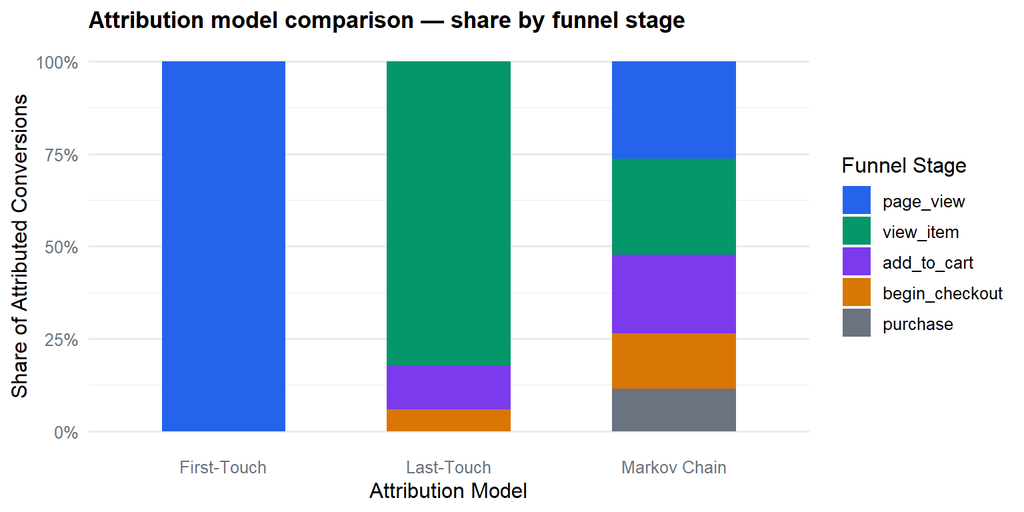

```r
plot_data <- heuristic_results |>
  select(channel_name, first_touch, last_touch) |>
  left_join(
    table_markov |>
      mutate(markov = percent / 100) |>
      select(channel, markov),
    by = c("channel_name" = "channel")
  ) |>
  tidyr::pivot_longer(
    cols      = c(first_touch, last_touch, markov),
    names_to  = "model",
    values_to = "value"
  ) |>
  mutate(
    model        = dplyr::recode(model,
      first_touch = "First-Touch",
      last_touch  = "Last-Touch",
      markov      = "Markov Chain"
    ),
    channel_name = factor(channel_name, levels = funnel_order)
  )

ggplot(plot_data, aes(x = model, y = value, fill = channel_name)) +
  geom_col(position = "fill", width = 0.55) +
  scale_y_continuous(labels = scales::percent_format()) +
  scale_fill_manual(values = c(
    "page_view"      = "#2563EB",
    "view_item"      = "#059669",
    "add_to_cart"    = "#7C3AED",
    "begin_checkout" = "#D97706",
    "purchase"       = "#6B7280"
  )) +
  labs(
    title = "Attribution model comparison — share by funnel stage",
    x     = "Attribution Model",
    y     = "Share of Attributed Conversions",
    fill  = "Funnel Stage"
  ) +
  theme_minimal(base_size = 12) +
  theme(
    plot.title         = element_text(face = "bold", size = 13),
    panel.grid.major.x = element_blank(),
    axis.text          = element_text(color = "#6B7280")
  )
```

### Transition Matrix Heatmap

```r
trans_1st <- transition_matrix(
  channel_stack,
  var_path = "cleaned_path",
  var_conv = "conversion",
  var_null = "non_conversion",
  order    = 1,
  sep      = ">"
)
```

```
[1] "*** Install ChannelAttribution Pro for free running install_pro(). Visit https://channelattribution.io for more info. Set flg_pro=FALSE to hide this message."
```

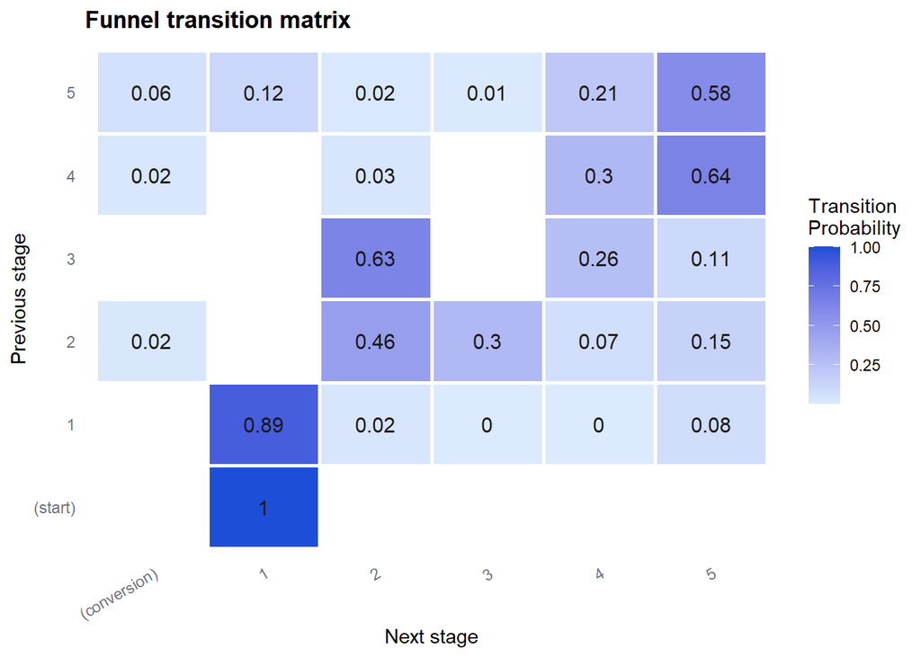

```r
ggplot(
  trans_1st$transition_matrix,
  aes(x = channel_to, y = channel_from, fill = transition_probability)
) +
  geom_tile(color = "white", linewidth = 1) +
  geom_text(
    aes(label = round(transition_probability, 2)),
    size = 4, color = "#1a1a1a"
  ) +
  scale_fill_gradient(low = "#DBEAFE", high = "#1D4ED8") +
  labs(
    title = "Funnel transition matrix",
    x     = "Next stage",
    y     = "Previous stage",
    fill  = "Transition\nProbability"
  ) +
  theme_minimal(base_size = 11) +
  theme(
    plot.title   = element_text(face = "bold", size = 13),
    axis.text.x  = element_text(angle = 30, hjust = 1, color = "#6B7280"),
    axis.text.y  = element_text(color = "#6B7280"),
    panel.grid   = element_blank()
  )
```

**Interpretation:** The heatmap shows the probability of a user moving from one funnel stage to the next. Darker blue cells indicate stronger transitions. Any light-colored cells on the conversion diagonal show where transition probability is weak — those are your highest-priority friction points.

## Recommendations

### Recommendation 1 — Fix Landing-to-Product Discovery Drop-off

The **78.4% drop** between `page_view` and `view_item` is the highest-priority problem. Of 2,499 users who landed on the site, only 539 ever viewed a product. Most users are bouncing before they engage with any product at all.

**Actions:**

- Add prominent product categories and featured items above the fold
- Improve internal search and filtering so users find relevant products quickly
- A/B test homepage layouts to identify which entry points drive the most `view_item` events

### Recommendation 2 — Optimize the Product Detail Page

Of the 539 users who viewed a product, only 98 added one to their cart — an **81.8% drop-off**. Users are reaching the product but not acting on it.

**Actions:**

- Add customer reviews and star ratings to all product pages
- Introduce urgency signals such as low stock indicators or limited-time offers
- Rewrite product descriptions to lead with benefits rather than features
- A/B test CTA button copy, size, and placement

**Expected impact:** A 10-point improvement increases add-to-cart users from 98 to approximately 152, directly expanding the checkout pool.

### Recommendation 3 — Reduce Checkout Abandonment

Of the 54 users who began checkout, only 17 completed a purchase — a **68.5% abandonment rate**. These users had clear purchase intent, so the barrier is the checkout process itself.

**Actions:**

- Implement guest checkout to remove account creation friction
- Reduce required form fields to the minimum necessary
- Display security badges, accepted payment methods, and return policy prominently
- Ensure checkout is fully optimized for mobile

**Expected impact:** Reducing abandonment by 20 points would increase purchases from 17 to approximately 27, lifting CVR from 0.7% to approximately 1.1%.

## Limitations

[output not shown]

## Reproducible Code & Instructions

### Requirements

Install the following R packages before rendering:

```r
install.packages(c(
  "bigrquery", "dplyr", "dbplyr", "ggplot2",
  "scales", "knitr", "kableExtra",
  "ChannelAttribution", "tidyr", "DBI", "htmltools"
))
```

### Authentication

```r
bigrquery::bq_auth(
  scopes = "https://www.googleapis.com/auth/bigquery"
)
```

### Render

From your terminal in the project directory:

```bash
quarto render Deliverable_2_Final.qmd
```

Or from RStudio: open the file and click **Render**.

### Repository

All code, data connections, and rendered outputs are available at: https://github.com/MattPradoCalPoly/project-IBM6530

```r
DBI::dbDisconnect(con)
```